# Домашняя работа 1

Мезенцева Алена

19 ноября 2016 г

## Исходные данные

Набор данных об осадках в Канаде с 1960 по 1980 годы: http://www.stats.uwo.ca/faculty/braun/data/rnf6080.dat.

## Работа с данными

- Загрузите данные в датафрейм, который назовите data.df.

```r
data.df <- read.table("http://www.stats.uwo.ca/faculty/braun/data/rnf6080.dat")
```

- Сколько строк и столбцов в data.df?

```r
# Строки:
nrow(data.df)
```

```
## [1] 5070
```

```r
# Колонки
ncol(data.df)
```

```
## [1] 27
```

- Получите имена колонок

```r
colnames(data.df)
```

```
##  [1] "V1"  "V2"  "V3"  "V4"  "V5"  "V6"  "V7"  "V8"  "V9"  "V10" "V11"
## [12] "V12" "V13" "V14" "V15" "V16" "V17" "V18" "V19" "V20" "V21" "V22"
## [23] "V23" "V24" "V25" "V26" "V27"
```

- Найдите значение из 5 строки седьмого столбца

```r
data.df[5,7]
```

```
## [1] 0
```

- Напечатайте целиком 2 строку

```r
data.df[2,]
```

```
##   V1 V2 V3 V4 V5 V6 V7 V8 V9 V10 V11 V12 V13 V14 V15 V16 V17 V18 V19 V20
## 2 60  4  2  0  0  0  0  0  0   0   0   0   0   0   0   0   0   0   0   0
##   V21 V22 V23 V24 V25 V26 V27
## 2   0   0   0   0   0   0   0
```

- Объясните, что делает следующая строка кода names(data.df) <- c(“year”, “month”, “day”, seq(0,23)). Воспользуйтесь функциями head и tail, чтобы просмотреть таблицу. Что представляют собой последние 24 колонки?

```r
names(data.df) <- c("year", "month", "day", seq(0,23))
# Данная строка переименовывает столбцы.
```

```r
head(data.df)
```

```
##   year month day 0 1 2 3 4 5 6 7 8 9 10 11 12 13 14 15 16 17 18 19 20 21
## 1   60     4   1 0 0 0 0 0 0 0 0 0 0  0  0  0  0  0  0  0  0  0  0  0  0
## 2   60     4   2 0 0 0 0 0 0 0 0 0 0  0  0  0  0  0  0  0  0  0  0  0  0
## 3   60     4   3 0 0 0 0 0 0 0 0 0 0  0  0  0  0  0  0  0  0  0  0  0  0
## 4   60     4   4 0 0 0 0 0 0 0 0 0 0  0  0  0  0  0  0  0  0  0  0  0  0
## 5   60     4   5 0 0 0 0 0 0 0 0 0 0  0  0  0  0  0  0  0  0  0  0  0  0
## 6   60     4   6 0 0 0 0 0 0 0 0 0 0  0  0  0  0  0  0  0  0  0  0  0  0
##   22 23
## 1  0  0
## 2  0  0
## 3  0  0
## 4  0  0
## 5  0  0
## 6  0  0
```

```r
tail(data.df)
```

```
##      year month day 0 1 2 3 4 5 6 7 8 9 10 11 12 13 14 15 16 17 18 19 20
## 5065   80    11  25 0 0 0 0 0 0 0 0 0 0  0  0  0  0  0  0  0  0  0  0  0
## 5066   80    11  26 0 0 0 0 0 0 0 0 0 0  0  0  0  0  0  0  0  0  0  0  0
## 5067   80    11  27 0 0 0 0 0 0 0 0 0 0  0  0  0  0  0  0  0  0  0  0  0
## 5068   80    11  28 0 0 0 0 0 0 0 0 0 0  0  0  0  0  0  0  0  0  0  0  0
## 5069   80    11  29 0 0 0 0 0 0 0 0 0 0  0  0  0  0  0  0  0  0  0  0  0
## 5070   80    11  30 0 0 0 0 0 0 0 0 0 0  0  0  0  0  0  0  0  0  0  0  0
##      21 22 23
## 5065  0  0  0
## 5066  0  0  0
## 5067  0  0  0
## 5068  0  0  0
## 5069  0  0  0
## 5070  0  0  0
```

```r
# Последние 24 колонки - количество осадков в определенное время суток (в часах).
```

- Добавьте новую колонку с названием daily, в которую запишите сумму крайних правых 24 колонок. Постройте гистограмму по этой колонке. Какие выводы можно сделать?

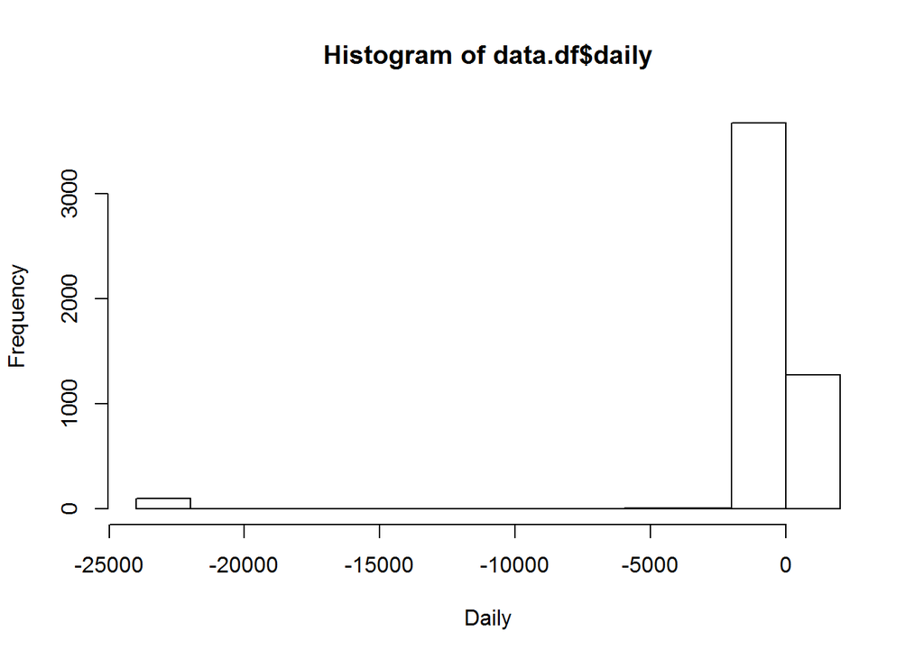

```r
data.df$daily <- rowSums(data.df[,c("0","1","2","3","4","5","6","7","8","9","10","11","12","13","14","15","16","17","18","19","20","21","22","23")],na.rm=TRUE)
hist(data.df$daily, xlab = "Daily")
```

```r
# Присутствуют отрицательные результаты, чего быть не должно.
```

- Создайте новый датафрейм fixed.df в котром исправьте замеченную ошибку. Постройте новую гистограмму, поясните почему она более корректна.

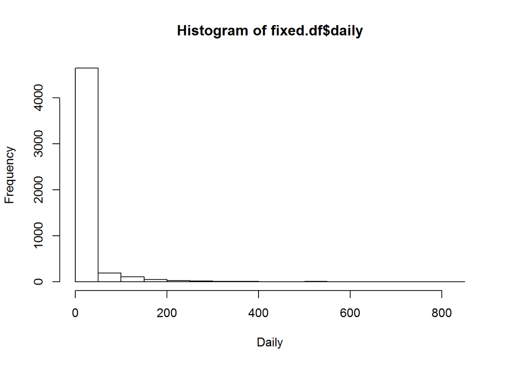

```r
fixed.df <- data.df
d<-array(dim(fixed.df),dim=c(1,2))
for(i in 1:d[,1]){
for(j in 1:d[,2]){
if(fixed.df[i,j] >= 0) fixed.df[i,j] else fixed.df[i,j]=0
}
}
hist(fixed.df$daily, xlab = "Daily")
```

```r
# Исключены отрицательные значения.
```

## Синтаксис и типизирование

- Для каждой строки кода поясните полученный результат, либо объясните почему она ошибочна.

```r
v <- c("4", "8", "15", "16", "23", "42")
max(v)
```

```
## [1] "8"
```

```r
sort(v)
```

```
## [1] "15" "16" "23" "4"  "42" "8"
```

```r
#sum(v)
# Создана последовательность символов. Для корректного выполнения функций это должны быть числа:
v <- c(4, 8, 15, 16, 23, 42)
max(v)
```

```
## [1] 42
```

```r
sort(v)
```

```
## [1]  4  8 15 16 23 42
```

```r
sum(v)
```

```
## [1] 108
```

- Для следующих наборов команд поясните полученный результат, либо объясните почему они ошибочны.

```r
v2 <- c("5",7,12)
#v2[2] + v2[3]

df3 <- data.frame(z1="5",z2=7,z3=12)
df3[1,2] + df3[1,3]
```

```
## [1] 19
```

```r
l4 <- list(z1="6", z2=42, z3="49", z4=126)
l4[[2]] + l4[[4]]
```

```
## [1] 168
```

```r
#l4[2] + l4[4]
# Для последовательности v2 невозможно просуммировать элементы 2 и 3, т.к. элемент 2 является символом.
# Датафрейм корректно сложил числа, потому что он может содержать переменные разного типа.
# В первом случае для списка числа сложились корректно, а во втором случае сложение невозможно, т.к. в данном случае элементом выступает z2=42, а не 42.
```

## Работа с функциями и операторами

- Оператор двоеточие создаёт последовательность целых чисел по порядку. Этот оператор — частный случай функции seq(), которую вы использовали раньше. Изучите эту функцию, вызвав команду ?seq. Испольуя полученные знания выведите на экран:
- Числа от 1 до 10000 с инкрементом 372.

```r
seq(from = 1, to = 10000, by = 372)
```

```
##  [1]    1  373  745 1117 1489 1861 2233 2605 2977 3349 3721 4093 4465 4837
## [15] 5209 5581 5953 6325 6697 7069 7441 7813 8185 8557 8929 9301 9673
```

```r
seq(from = 1, to = 10000, by = 50)
```

```
##   [1]    1   51  101  151  201  251  301  351  401  451  501  551  601  651
##  [15]  701  751  801  851  901  951 1001 1051 1101 1151 1201 1251 1301 1351
##  [29] 1401 1451 1501 1551 1601 1651 1701 1751 1801 1851 1901 1951 2001 2051
##  [43] 2101 2151 2201 2251 2301 2351 2401 2451 2501 2551 2601 2651 2701 2751
##  [57] 2801 2851 2901 2951 3001 3051 3101 3151 3201 3251 3301 3351 3401 3451
##  [71] 3501 3551 3601 3651 3701 3751 3801 3851 3901 3951 4001 4051 4101 4151
##  [85] 4201 4251 4301 4351 4401 4451 4501 4551 4601 4651 4701 4751 4801 4851
##  [99] 4901 4951 5001 5051 5101 5151 5201 5251 5301 5351 5401 5451 5501 5551
## [113] 5601 5651 5701 5751 5801 5851 5901 5951 6001 6051 6101 6151 6201 6251
## [127] 6301 6351 6401 6451 6501 6551 6601 6651 6701 6751 6801 6851 6901 6951
## [141] 7001 7051 7101 7151 7201 7251 7301 7351 7401 7451 7501 7551 7601 7651
## [155] 7701 7751 7801 7851 7901 7951 8001 8051 8101 8151 8201 8251 8301 8351
## [169] 8401 8451 8501 8551 8601 8651 8701 8751 8801 8851 8901 8951 9001 9051
## [183] 9101 9151 9201 9251 9301 9351 9401 9451 9501 9551 9601 9651 9701 9751
## [197] 9801 9851 9901 9951
```

- Функция rep() повторяет переданный вектор указанное число раз. Объясните разницу между rep(1:5,times=3) и rep(1:5, each=3).

```r
rep(1:5,times=3)
```

```
##  [1] 1 2 3 4 5 1 2 3 4 5 1 2 3 4 5
```

```r
rep(1:5, each=3)
```

```
##  [1] 1 1 1 2 2 2 3 3 3 4 4 4 5 5 5
```

```r
# В первом случае весь вектор повторяется 3 раза, а во втором - каждый элемент повторяется 3 раза.
```